# PAC2 Análisis Datos Omicos

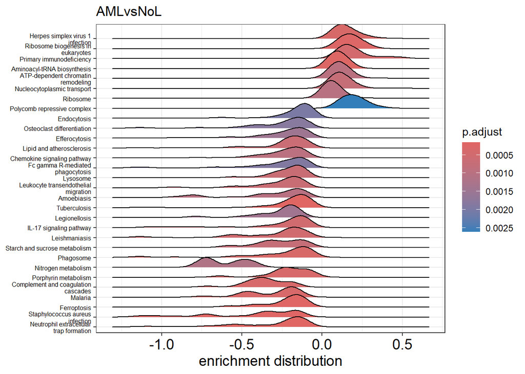

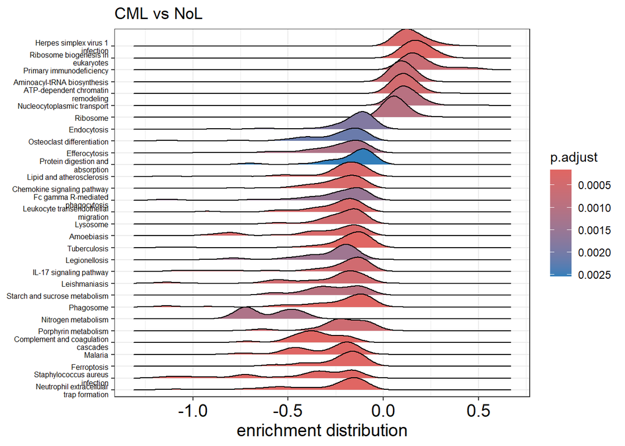

En el RidgePlot observamos la distribución de enriquecimiento de las vías metabólicas mencionadas en el eje ‘y’.

Esto nos permite una vez más ver de forma distinta que procesos KEGG estan diferencialmente expresados en cada condicion y cual es exactamente la distribución de estas diferencias.

Las distribuciones superiores a 0 en el eje de las ‘x’ indican sobrexpresión, mientras que las distribuciones con valores inferiores a 0 representan subexpresión.

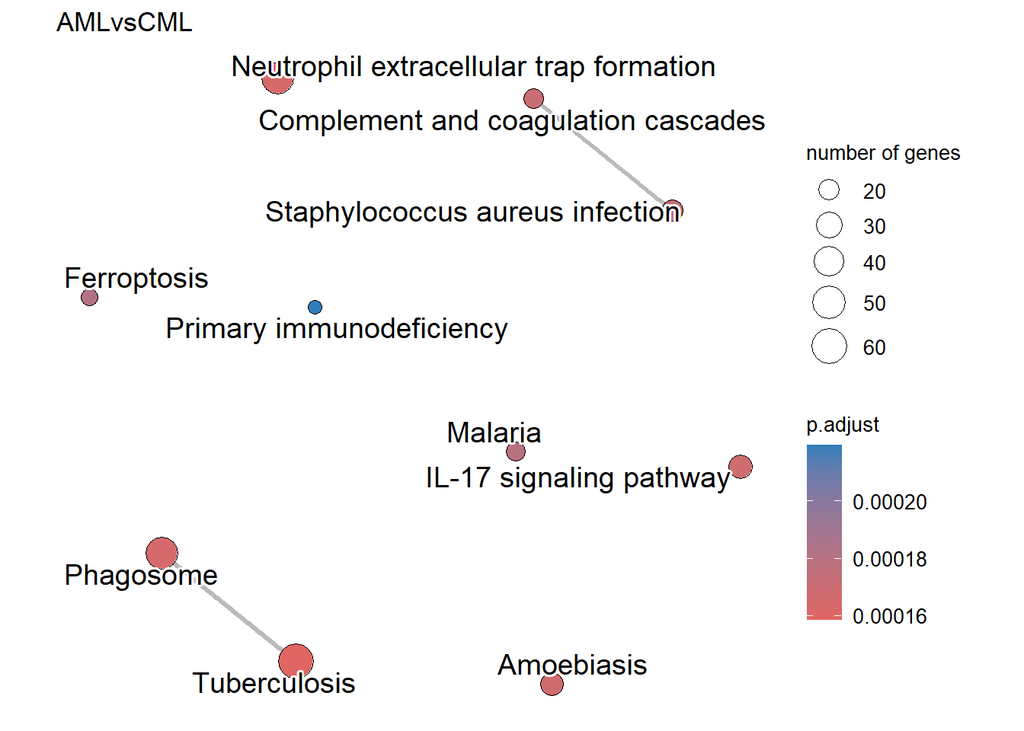

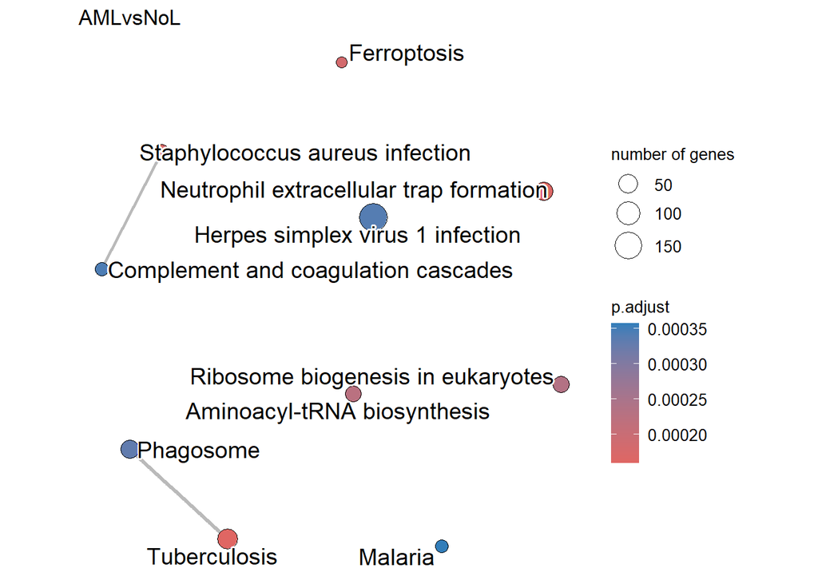

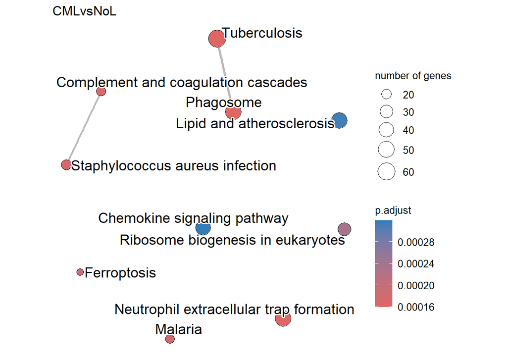

En los mapas AMLvsNoL y CMLvsNoL no encontramos agrupaciones importantes que impliquen 3 gene sets o más.